# Experiment 2: NYC Airline Data

2023-09-11

This is a notebook that is derived from an experiment done in DS241.

It will consist the loading of NYC flight data, finding unique flight numbers in flights to Miami in September, creating a data frame called df6, which is composed of flights to Miami with a flight number matching the smallest flight number from the given set stated above, creating a visualization (using ggplot) to show DELAYS associated with this flight number, and creating another visualization that helps understand the relationship between the arrival delay and the departure delay.

First, we will load our needed libraries.

```r
library(nycflights13)
library(tidyverse)
library(here)
library(janitor)
```

Now, we will load our flight data into a variable named df1.

```r
df1 = flights
glimpse(df1)
```

```
Rows: 336,776
Columns: 19
$ year           <int> 2013, 2013, 2013, 2013, 2013, 2013, 2013, 2013, 2013, 2013, 2013, 2013, 2013, 2013,…
$ month          <int> 1, 1, 1, 1, 1, 1, 1, 1, 1, 1, 1, 1, 1, 1, 1, 1, 1, 1, 1, 1, 1, 1, 1, 1, 1, 1, 1, 1,…
$ day            <int> 1, 1, 1, 1, 1, 1, 1, 1, 1, 1, 1, 1, 1, 1, 1, 1, 1, 1, 1, 1, 1, 1, 1, 1, 1, 1, 1, 1,…
$ dep_time       <int> 517, 533, 542, 544, 554, 554, 555, 557, 557, 558, 558, 558, 558, 558, 559, 559, 559…
$ sched_dep_time <int> 515, 529, 540, 545, 600, 558, 600, 600, 600, 600, 600, 600, 600, 600, 600, 559, 600…
$ dep_delay      <dbl> 2, 4, 2, -1, -6, -4, -5, -3, -3, -2, -2, -2, -2, -2, -1, 0, -1, 0, 0, 1, -8, -3, -4…
$ arr_time       <int> 830, 850, 923, 1004, 812, 740, 913, 709, 838, 753, 849, 853, 924, 923, 941, 702, 85…
$ sched_arr_time <int> 819, 830, 850, 1022, 837, 728, 854, 723, 846, 745, 851, 856, 917, 937, 910, 706, 90…
$ arr_delay      <dbl> 11, 20, 33, -18, -25, 12, 19, -14, -8, 8, -2, -3, 7, -14, 31, -4, -8, -7, 12, -6, -…
$ carrier        <chr> "UA", "UA", "AA", "B6", "DL", "UA", "B6", "EV", "B6", "AA", "B6", "B6", "UA", "UA",…
$ flight         <int> 1545, 1714, 1141, 725, 461, 1696, 507, 5708, 79, 301, 49, 71, 194, 1124, 707, 1806,…
$ tailnum        <chr> "N14228", "N24211", "N619AA", "N804JB", "N668DN", "N39463", "N516JB", "N829AS", "N5…
$ origin         <chr> "EWR", "LGA", "JFK", "JFK", "LGA", "EWR", "EWR", "LGA", "JFK", "LGA", "JFK", "JFK",…
$ dest           <chr> "IAH", "IAH", "MIA", "BQN", "ATL", "ORD", "FLL", "IAD", "MCO", "ORD", "PBI", "TPA",…
$ air_time       <dbl> 227, 227, 160, 183, 116, 150, 158, 53, 140, 138, 149, 158, 345, 361, 257, 44, 337, …
$ distance       <dbl> 1400, 1416, 1089, 1576, 762, 719, 1065, 229, 944, 733, 1028, 1005, 2475, 2565, 1389…
$ hour           <dbl> 5, 5, 5, 5, 6, 5, 6, 6, 6, 6, 6, 6, 6, 6, 6, 5, 6, 6, 6, 6, 6, 6, 6, 6, 6, 6, 6, 6,…
$ minute         <dbl> 15, 29, 40, 45, 0, 58, 0, 0, 0, 0, 0, 0, 0, 0, 0, 59, 0, 0, 0, 0, 10, 5, 10, 10, 7,…
$ time_hour      <dttm> 2013-01-01 05:00:00, 2013-01-01 05:00:00, 2013-01-01 05:00:00, 2013-01-01 05:00:00…
```

Next, we will find the unique flight numbers for flights to Miami in September. To begin, we will create a variable, called df3, that will hold the flights to Miami in September

```r
df3 = df1 |> filter(month == 9, dest == "MIA")
glimpse(df3)
```

```
Rows: 912
Columns: 19
$ year           <int> 2013, 2013, 2013, 2013, 2013, 2013, 2013, 2013, 2013, 2013, 2013, 2013, 2013, 2013,…
$ month          <int> 9, 9, 9, 9, 9, 9, 9, 9, 9, 9, 9, 9, 9, 9, 9, 9, 9, 9, 9, 9, 9, 9, 9, 9, 9, 9, 9, 9,…
$ day            <int> 1, 1, 1, 1, 1, 1, 1, 1, 1, 1, 1, 1, 1, 1, 1, 1, 1, 1, 1, 1, 1, 1, 1, 1, 1, 1, 2, 2,…
$ dep_time       <int> 537, 552, 619, 705, 727, 822, 911, 939, 1034, 1102, 1143, 1155, 1243, 1301, 1356, 1…
$ sched_dep_time <int> 545, 600, 629, 710, 735, 829, 915, 950, 1035, 1110, 1145, 1159, 1245, 1310, 1345, 1…
$ dep_delay      <dbl> -8, -8, -10, -5, -8, -7, -4, -11, -1, -8, -2, -4, -2, -9, 11, -13, -4, -3, -13, -11…
$ arr_time       <int> 849, 843, 900, 951, 1017, 1108, 1206, 1215, 1320, 1406, 1430, 1450, 1529, 1533, 164…
$ sched_arr_time <int> 855, 905, 929, 1025, 1035, 1139, 1230, 1310, 1349, 1430, 1450, 1514, 1600, 1615, 17…
$ arr_delay      <dbl> -6, -22, -29, -34, -18, -31, -24, -55, -29, -24, -20, -24, -31, -42, -20, -16, 0, -…
$ carrier        <chr> "AA", "AA", "AA", "AA", "AA", "AA", "AA", "AA", "DL", "AA", "AA", "AA", "AA", "UA",…
$ flight         <int> 701, 1895, 1921, 1165, 1713, 1938, 647, 1813, 874, 1153, 1623, 2093, 2041, 1401, 16…
$ tailnum        <chr> "N613AA", "N3KFAA", "N3CTAA", "N338AA", "N3KGAA", "N3KNAA", "N5FRAA", "N3DRAA", "N3…
$ origin         <chr> "JFK", "LGA", "EWR", "JFK", "LGA", "LGA", "JFK", "LGA", "LGA", "LGA", "EWR", "LGA",…
$ dest           <chr> "MIA", "MIA", "MIA", "MIA", "MIA", "MIA", "MIA", "MIA", "MIA", "MIA", "MIA", "MIA",…
$ air_time       <dbl> 148, 149, 140, 143, 147, 146, 147, 141, 145, 140, 141, 157, 143, 138, 146, 147, 153…
$ distance       <dbl> 1089, 1096, 1085, 1089, 1096, 1096, 1089, 1096, 1096, 1096, 1085, 1096, 1089, 1085,…
$ hour           <dbl> 5, 6, 6, 7, 7, 8, 9, 9, 10, 11, 11, 11, 12, 13, 13, 15, 15, 15, 16, 17, 16, 17, 18,…
$ minute         <dbl> 45, 0, 29, 10, 35, 29, 15, 50, 35, 10, 45, 59, 45, 10, 45, 0, 5, 59, 20, 15, 20, 35…
$ time_hour      <dttm> 2013-09-01 05:00:00, 2013-09-01 06:00:00, 2013-09-01 06:00:00, 2013-09-01 07:00:00…
```

Then, we will create a variable, called unique_df3, that will find the unique flight numbers in the flights composed in df3.

```r
unique_df3 = df3 |> distinct(flight) |> arrange(flight)
glimpse(unique_df3)
```

```
Rows: 57
Columns: 1
$ flight <int> 83, 145, 172, 446, 476, 577, 613, 647, 701, 825, 874, 1073, 1153, 1158, 1160, 1165, 1175, 1…
```

We will now create the data frame df6, which will compose of flights to Miami with the smallest flight number from the set above.

```r
df6 = df1 %>% filter (dest == "MIA", flight == 83)
glimpse(df6)
```

```
Rows: 146
Columns: 19
$ year           <int> 2013, 2013, 2013, 2013, 2013, 2013, 2013, 2013, 2013, 2013, 2013, 2013, 2013, 2013,…
$ month          <int> 10, 10, 10, 10, 10, 10, 10, 10, 10, 10, 10, 10, 10, 10, 10, 10, 10, 10, 10, 10, 10,…
$ day            <int> 1, 2, 3, 4, 5, 6, 7, 8, 9, 10, 11, 12, 13, 14, 15, 16, 17, 18, 19, 20, 21, 22, 23, …
$ dep_time       <int> 1813, 1811, 1812, 1814, 1838, 1812, 1904, 1808, 1811, 1813, 1846, 1853, 1812, 1812,…
$ sched_dep_time <int> 1814, 1814, 1814, 1814, 1820, 1814, 1814, 1814, 1814, 1814, 1814, 1820, 1814, 1814,…
$ dep_delay      <dbl> -1, -3, -2, 0, 18, -2, 50, -6, -3, -1, 32, 33, -2, -2, -4, -2, -1, -3, -5, -5, -6, …
$ arr_time       <int> 2047, 2100, 2056, 2049, 2118, 2135, 2215, 2104, 2121, 2101, 2136, 2138, 2109, 2048,…
$ sched_arr_time <int> 2143, 2143, 2143, 2143, 2146, 2143, 2143, 2143, 2143, 2143, 2143, 2146, 2143, 2143,…
$ arr_delay      <dbl> -56, -43, -47, -54, -28, -8, 32, -39, -22, -42, -7, -8, -34, -55, -43, -53, -42, -4…
$ carrier        <chr> "DL", "DL", "DL", "DL", "DL", "DL", "DL", "DL", "DL", "DL", "DL", "DL", "DL", "DL",…
$ flight         <int> 83, 83, 83, 83, 83, 83, 83, 83, 83, 83, 83, 83, 83, 83, 83, 83, 83, 83, 83, 83, 83,…
$ tailnum        <chr> "N975DL", "N964DL", "N919DL", "N969DL", "N907DE", "N905DE", "N946DL", "N925DL", "N9…
$ origin         <chr> "JFK", "JFK", "JFK", "JFK", "JFK", "JFK", "JFK", "JFK", "JFK", "JFK", "JFK", "JFK",…
$ dest           <chr> "MIA", "MIA", "MIA", "MIA", "MIA", "MIA", "MIA", "MIA", "MIA", "MIA", "MIA", "MIA",…
$ air_time       <dbl> 137, 144, 145, 134, 137, 140, 150, 152, 150, 149, 143, 134, 140, 137, 135, 143, 149…
$ distance       <dbl> 1089, 1089, 1089, 1089, 1089, 1089, 1089, 1089, 1089, 1089, 1089, 1089, 1089, 1089,…
$ hour           <dbl> 18, 18, 18, 18, 18, 18, 18, 18, 18, 18, 18, 18, 18, 18, 18, 18, 18, 18, 18, 18, 18,…
$ minute         <dbl> 14, 14, 14, 14, 20, 14, 14, 14, 14, 14, 14, 20, 14, 14, 14, 14, 14, 14, 20, 14, 14,…
$ time_hour      <dttm> 2013-10-01 18:00:00, 2013-10-02 18:00:00, 2013-10-03 18:00:00, 2013-10-04 18:00:00…
```

Now, we will create a visualization (using ggplot) to show the DELAYS associated with this flight number.

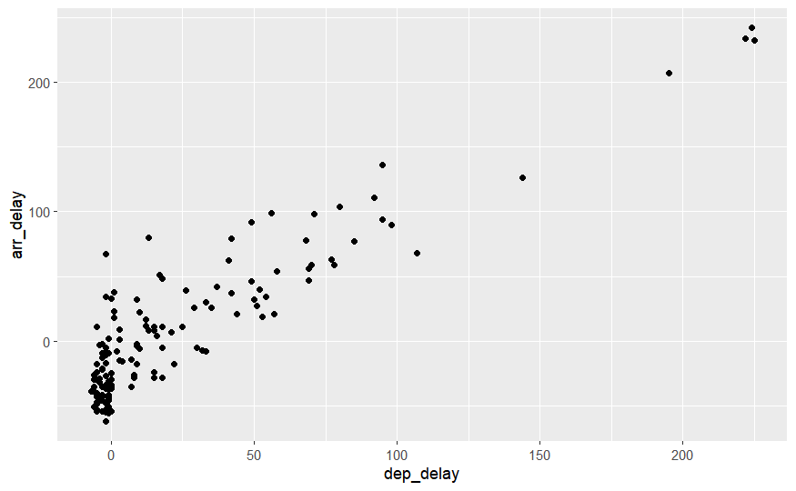

```r
df6 |> ggplot(aes(x = dep_delay, y = arr_delay)) +geom_point()
```

Finally, we will create a visualization that helps to understand the relationship between the arrival delay and the departure delay.

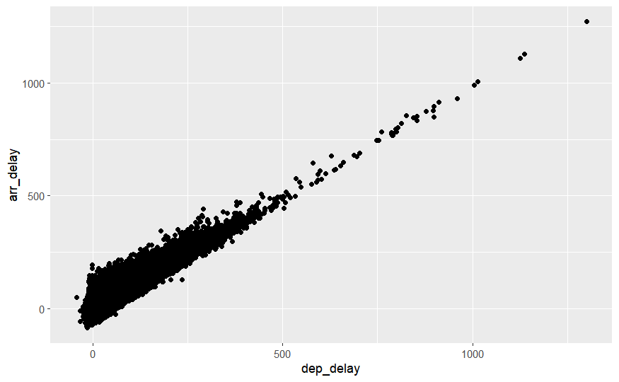

```r
flights |> ggplot(aes(x = dep_delay, y = arr_delay)) +geom_point()
```

We can see from the visual that the arrival delay and departure delay are similar enough in time to one another. Example: if a flight departed ~20 minutes late, you can expect to arrive ~20 minutes late. Generally, the arrival delays and departure delays are right-skewed, meaning the delays are not very long. Any “delay” value that is negative, means that it was early; so if arrival delay is negative, then it arrived early, and if departure delay is negative, then the flight left early.

## Another visualization

```r
df1 |>
  filter(dest == "MIA") |>
  count(origin, sort = TRUE)
```

| origin | n |
| --- | --- |
| LGA | 5781 |
| JFK | 3314 |
| EWR | 2633 |

## Is flight time affect by delayed departure?

I want to examine whether the flight time is impacted by delayed departure

I want to compare flight time to “planned” flight time. So we create a new variable called flt_delta.

A flight that arrives 10 minutes later, if it departed on time, had a “delta” of 10 minutes.

```r
df7 = df1 |>
  filter(dest == "MIA", origin == "LGA") |>
  mutate(flt_delta = arr_delay - dep_delay)
```

```r
df7 |>
  ggplot(aes(x = dep_delay, y = flt_delta)) +geom_point(alpha = 0.1)
```

[output not shown]

```r
df7 |>
  ggplot(aes(x = dep_delay, y = flt_delta)) +geom_point(alpha = 0.1) +
  geom_hline(aes(yintercept = mean(flt_delta, na.rm = TRUE)))
```

[output not shown]

### Is departure delat affect by time of year

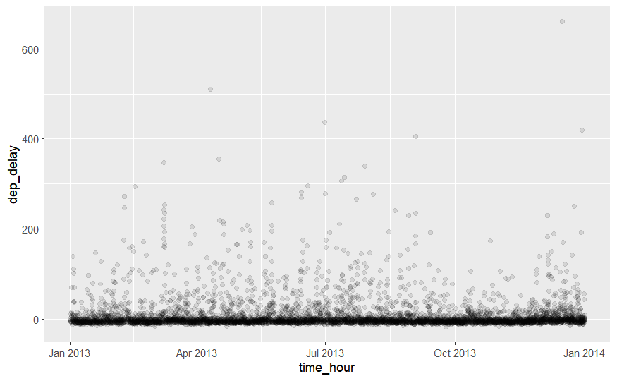

```r
df7 |>
  ggplot(aes(x = time_hour, y = dep_delay)) +geom_point(alpha = 0.1)
```

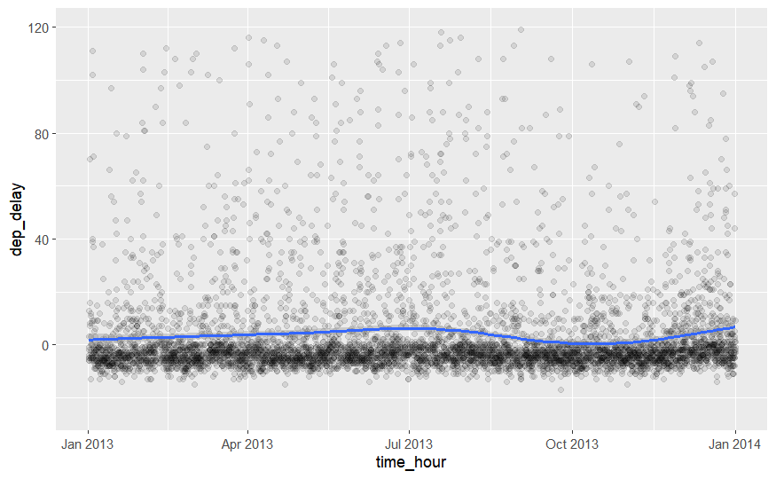

```r
df7 |>
  ggplot(aes(x = time_hour, y = dep_delay)) +
  geom_point(alpha = 0.1) +
  stat_smooth() +
  ylim(-25, 120)
```

*Why are delays bigger in December than in January — probably not weather.*

### Does the departure delay change across time of day?

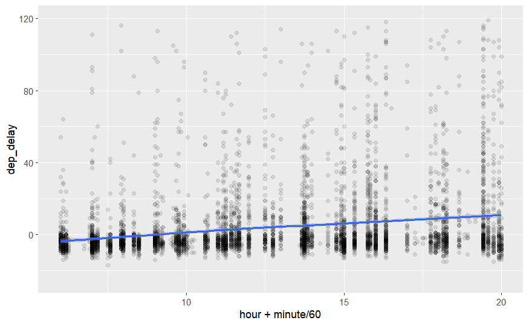

```r
df7 |>
  ggplot(aes(x = hour + minute / 60, y = dep_delay)) +
  geom_point(alpha = 0.1) +
  stat_smooth() +
  ylim(-25, 120)
```

Observation: * Departure delay increases across the flight day.

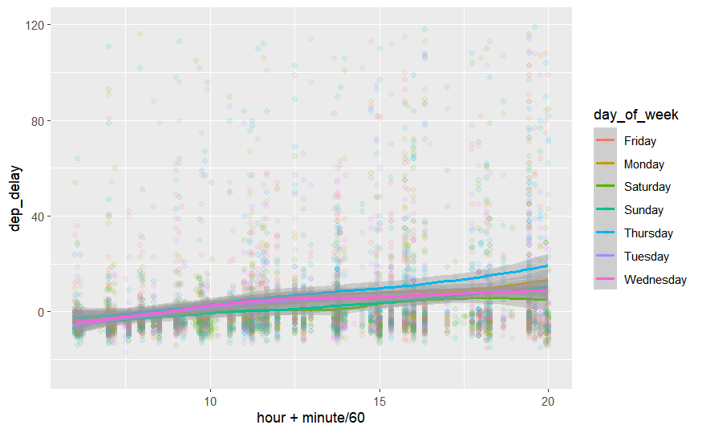

```r
df7 |>
  mutate(day_of_week = weekdays(time_hour)) |>
  ggplot(aes(x = hour + minute / 60, y = dep_delay, color = day_of_week)) +
  geom_point(alpha = 0.1) +
  stat_smooth() +
  ylim(-25, 120)
```

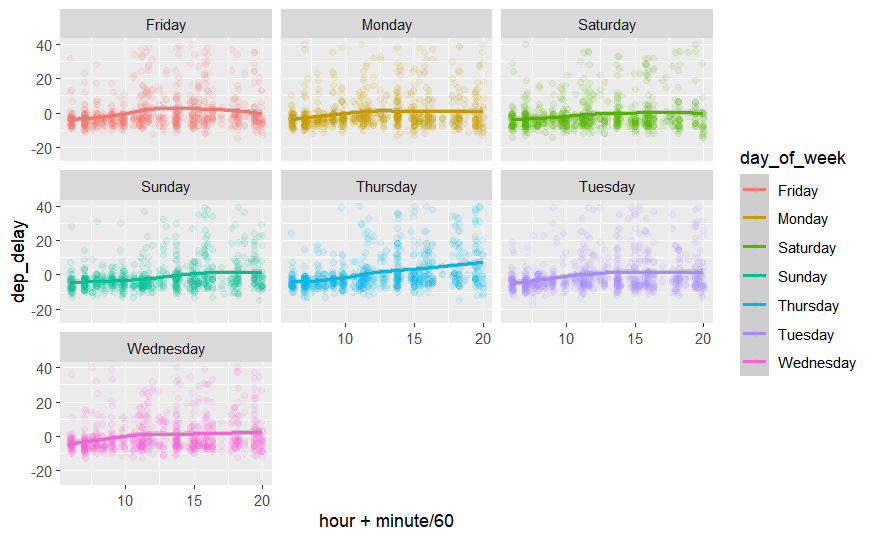

```r
df7 |>
  mutate(day_of_week = weekdays(time_hour)) |>
  ggplot(aes(x = hour + minute / 60, y = dep_delay, color = day_of_week)) +
  geom_point(alpha = 0.1) +
  stat_smooth() +
  ylim(-25, 40) +
  facet_wrap(~day_of_week)
```